# Data Cleaning and Standards Assignment

Katie Danyk

2026-09-28

# Step 1: Load the required packages and read in the raw data

Before I begin the assignment, I need to load the packages and ensure that my code is reproducible by recording package versions and establishing file paths.

### 1a. Load packages

```r
library(renv)
library(here)
library(tidyverse)
library(assertr)
library(skimr)
library(GGally)
```

### 1b. Record and lock package versions

I will do this with the ‘init()’ and ‘snapshot()’ commands from the package ‘renv’

```r
renv::init()
```

```
## - The project is out-of-sync -- use `renv::status()` for details.
```

```r
snapshot()
```

```
## The following package(s) will be updated in the lockfile:
##
## # CRAN -----------------------------------------------------------------------
## - GGally      [* -> 2.4.0]
## - ggstats     [* -> 0.14.0]
## - patchwork   [* -> 1.3.2]
##
## - Lockfile written to "/Volumes/KATIEDANYK/Reproducible Data Management/Data cleaning assignment/CIEE data cleaning assignment/renv.lock".
```

### 1c. Build file paths

I will do this using the ‘here’ package

```r
here::here(
  "Raw_data",
  "chl-a-samples-messy.csv"
)
```

```
## [1] "/Volumes/KATIEDANYK/Reproducible Data Management/Data cleaning assignment/CIEE data cleaning assignment/Raw_data/chl-a-samples-messy.csv"
```

```r
here::here(
  "Raw_data",
  "stations-messy.csv"
)
```

```
## [1] "/Volumes/KATIEDANYK/Reproducible Data Management/Data cleaning assignment/CIEE data cleaning assignment/Raw_data/stations-messy.csv"
```

```r
here::here(
  "Raw_data",
  "waterbodies-messy.csv"
)
```

```
## [1] "/Volumes/KATIEDANYK/Reproducible Data Management/Data cleaning assignment/CIEE data cleaning assignment/Raw_data/waterbodies-messy.csv"
```

### 1d. Read in raw data

I will use the ‘read_csv’ command from readr

```r
# messy chl a samples data
chl_a_messy <- read_csv("Raw_data/chl-a-samples-messy.csv")
# messy stations data
stations_messy <- read_csv("Raw_data/stations-messy.csv")
# messy waterbodies data
waterbodies_messy <- read_csv("Raw_data/waterbodies-messy.csv")
```

# Step 2: Explore the datasets

Before I can clean the data, I need to explore the structure, variable classes, distributions, and categorical values of each dataset. I also need to use an entity relationship diagram (ERD) to inspect the column names in each of the datasets and determine which shared identifier columns can be used to connect the datasets.

### 2a. Chl a dataset

```r
str(chl_a_messy)
```

```
## spc_tbl_ [1,578 × 15] (S3: spec_tbl_df/tbl_df/tbl/data.frame)
##  $ chl_a_sample_code        : chr [1:1578] "CHL0001" "CHL0002" "CHL0003" "CHL0004" ...
##  $ station_code             : chr [1:1578] "ST091" "ST068" "ST091" "ST095" ...
##  $ date                     : chr [1:1578] "1983-04-08" "1983-05-31" "1983-05-31" "1983-05-31" ...
##  $ sample_replicate         : num [1:1578] 1 1 1 1 2 1 1 1 1 1 ...
##  $ subsample_replicate      : num [1:1578] NA NA NA NA NA NA NA NA NA NA ...
##  $ sample_volume_filtered_ml: chr [1:1578] "1000" "1000" "1000" "1000" ...
##  $ extract_volume_ml        : num [1:1578] 5 7.1 5.5 6.4 7.5 6.4 5.8 7 7 9 ...
##  $ absorbance_750nm         : num [1:1578] 0.005 0.006 0.005 0.008 0.006 0.008 0.002 0.006 0.005 0.003 ...
##  $ absorbance_663nm         : chr [1:1578] "0.022" "0.024" "0.029" "0.024" ...
##  $ absorbance_645nm         : num [1:1578] 0.013 0.014 0.007 0.015 0.011 0.014 0.009 0.009 0.008 0.007 ...
##  $ absorbance_630nm         : num [1:1578] 0.011 0.012 0.012 0.015 0.009 0.013 0.01 0.008 0.007 0.007 ...
##  $ chl_a_16ed               : num [1:1578] 0.91 1.37 1.52 1.1 1.93 1.56 1.06 0.04 0.77 0.76 ...
##  $ chl_a_20ed               : num [1:1578] 0.95 391.05 1.55 1.15 1.99 ...
##  $ description              : chr [1:1578] NA NA NA NA ...
##  $ unit                     : chr [1:1578] "mg/L" "mg/L" "mg/L" "mg/L" ...
##  - attr(*, "spec")=
##   .. cols(
##   ..   chl_a_sample_code = col_character(),
##   ..   station_code = col_character(),
##   ..   date = col_character(),
##   ..   sample_replicate = col_double(),
##   ..   subsample_replicate = col_double(),
##   ..   sample_volume_filtered_ml = col_character(),
##   ..   extract_volume_ml = col_double(),
##   ..   absorbance_750nm = col_double(),
##   ..   absorbance_663nm = col_character(),
##   ..   absorbance_645nm = col_double(),
##   ..   absorbance_630nm = col_double(),
##   ..   chl_a_16ed = col_double(),
##   ..   chl_a_20ed = col_double(),
##   ..   description = col_character(),
##   ..   unit = col_character()
##   .. )
##  - attr(*, "problems")=<pointer: 0x981d65580>
```

```r
dim(chl_a_messy)
```

```
## [1] 1578   15
```

```r
head(chl_a_messy)
```

```
## # A tibble: 6 × 15
##   chl_a_sample_code station_code date       sample_replicate subsample_replicate
##   <chr>             <chr>        <chr>                 <dbl>               <dbl>
## 1 CHL0001           ST091        1983-04-08                1                  NA
## 2 CHL0002           ST068        1983-05-31                1                  NA
## 3 CHL0003           ST091        1983-05-31                1                  NA
## 4 CHL0004           ST095        1983-05-31                1                  NA
## 5 CHL0005           ST095        1983-05-31                2                  NA
## 6 CHL0006           ST065        1983-05-31                1                  NA
## # ℹ 10 more variables: sample_volume_filtered_ml <chr>,
## #   extract_volume_ml <dbl>, absorbance_750nm <dbl>, absorbance_663nm <chr>,
## #   absorbance_645nm <dbl>, absorbance_630nm <dbl>, chl_a_16ed <dbl>,
## #   chl_a_20ed <dbl>, description <chr>, unit <chr>
```

```r
skim(chl_a_messy)
```

Data summary

| Name | chl_a_messy |
| --- | --- |
| Number of rows | 1578 |
| Number of columns | 15 |
| _______________________ |  |
| Column type frequency: |  |
| character | 7 |
| numeric | 8 |
| ________________________ |  |
| Group variables | None |

**Variable type: character**

| skim_variable | n_missing | complete_rate | min | max | empty | n_unique | whitespace |
| --- | --- | --- | --- | --- | --- | --- | --- |
| chl_a_sample_code | 0 | 1.00 | 7 | 7 | 0 | 1578 | 0 |
| station_code | 0 | 1.00 | 5 | 5 | 0 | 70 | 0 |
| date | 0 | 1.00 | 10 | 13 | 0 | 218 | 0 |
| sample_volume_filtered_ml | 0 | 1.00 | 3 | 8 | 0 | 54 | 0 |
| absorbance_663nm | 0 | 1.00 | 1 | 5 | 0 | 114 | 0 |
| description | 671 | 0.57 | 28 | 29 | 0 | 3 | 0 |
| unit | 0 | 1.00 | 4 | 5 | 0 | 2 | 0 |

**Variable type: numeric**

| skim_variable | n_missing | complete_rate | mean | sd | p0 | p25 | p50 | p75 | p100 | hist |
| --- | --- | --- | --- | --- | --- | --- | --- | --- | --- | --- |
| sample_replicate | 12 | 0.99 | 1.72 | 0.81 | 1.0 | 1.00 | 2.00 | 2.00 | 5.00 | ▇▅▃▁▁ |
| subsample_replicate | 1182 | 0.25 | 1.50 | 0.50 | 1.0 | 1.00 | 1.00 | 2.00 | 2.00 | ▇▁▁▁▇ |
| extract_volume_ml | 0 | 1.00 | 11.24 | 2.27 | -9.8 | 10.30 | 11.50 | 12.60 | 17.40 | ▁▁▁▇▆ |
| absorbance_750nm | 0 | 1.00 | 0.00 | 0.01 | 0.0 | 0.00 | 0.00 | 0.00 | 0.20 | ▇▁▁▁▁ |
| absorbance_645nm | 0 | 1.00 | 0.01 | 0.06 | 0.0 | 0.00 | 0.01 | 0.01 | 0.76 | ▇▁▁▁▁ |
| absorbance_630nm | 0 | 1.00 | 0.01 | 0.02 | 0.0 | 0.00 | 0.00 | 0.01 | 0.38 | ▇▁▁▁▁ |
| chl_a_16ed | 0 | 1.00 | 3.30 | 4.75 | 0.0 | 1.37 | 2.16 | 3.90 | 70.68 | ▇▁▁▁▁ |
| chl_a_20ed | 0 | 1.00 | 3.70 | 11.05 | 0.0 | 1.42 | 2.24 | 4.03 | 391.05 | ▇▁▁▁▁ |

SUMMARY *str() output* From the str() output, I can see that the variables with the class ‘character’ are: - chl_a_sample_code - station_code - date - sample_volume_filtered_ml - absorbance_663nm - description - unit

I can also see that the variables with the class ‘numeric’ are: - sample_replicate - subsample_replicate - extract_volume_ml - absorbance_750nm - absorbance_645nm - absorbance_630nm - chl_a_16ed - chl_a_20ed

Based on the Data Dictionary, and the output of the str() command, I can tell that some of the variables are classed incorrectly: - sample_volume_filtered_ml should be ‘numeric’ - absorbance_663nm should be ‘numeric’ - sample_replicate should be ‘categorical’ because it can only be whole numbers - subsample_replicate should be ‘categorical’ because it can only be whole numbers

*dim() output* The dim() output tells me that there are 1578 rows and 15 columns.

*skim() output* From the skim() output, I can see that none of the ‘character’ variables have white spaces or missing values, except “description”, but this is okay because the Data Dictionary said it was not always recorded. I will refer back to the “n_unique” values in the skim() output for the “station_code” when I explore the stations dataset to make sure they match.

For the ‘numeric’ variable part of the skim() output, I can see that the only variables with missing values are “sample_replicate” and “subsample_replicate”. This is not a problem for “subsample_replicate” based on the Data Dictionary description, but the Data Dictionary does not mention missing values for “sample_replicate” so there are potentially errors here.

I can also see that “extract_volume_ml” has a -9.8 in the “p0” column, leading me to believe there is a typo in the “extract_volume_ml” column because this column should only contain positive values based on the Data Dictionary description.

Lastly, the “p100” column has a 70.680 and 391.050 for “chl_a_16ed” and “chl_a_20ed” respectively, which both seem a bit high compared to the means and sd’s and suggests that there might be typos in these columns.

Then, I’m going to look at the distributions of the ‘numeric’ variables with histograms

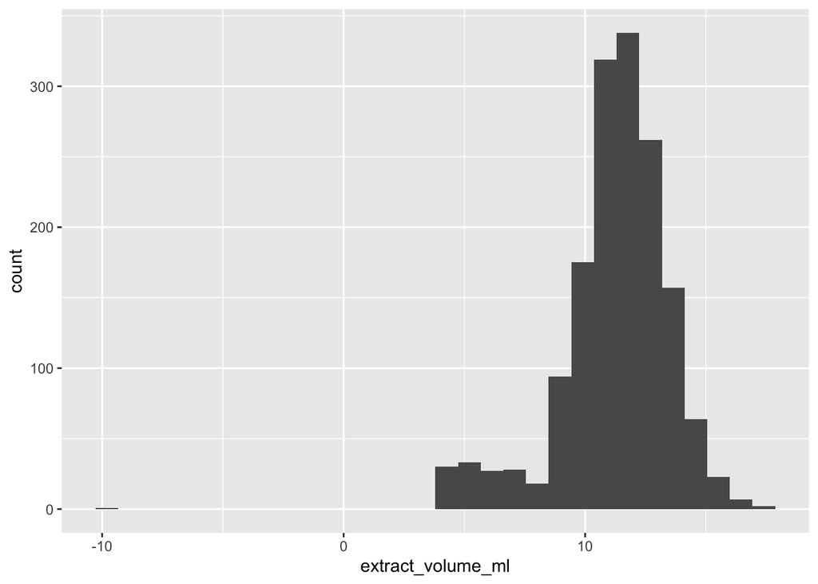

```r
ggplot() +
  geom_histogram(data = chl_a_messy, aes(x = extract_volume_ml))
```

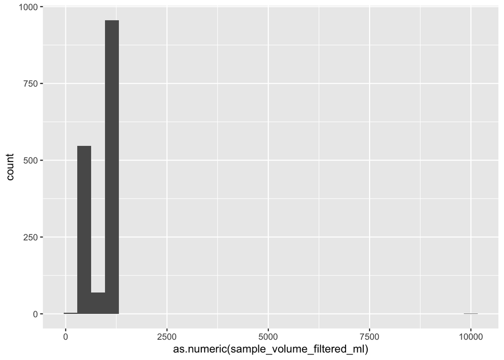

```r
ggplot() +
  geom_histogram(data = chl_a_messy, aes(x = as.numeric(sample_volume_filtered_ml))) # I'm coercing the variable to 'numeric' inside the plot only, just so I can see the distribution
```

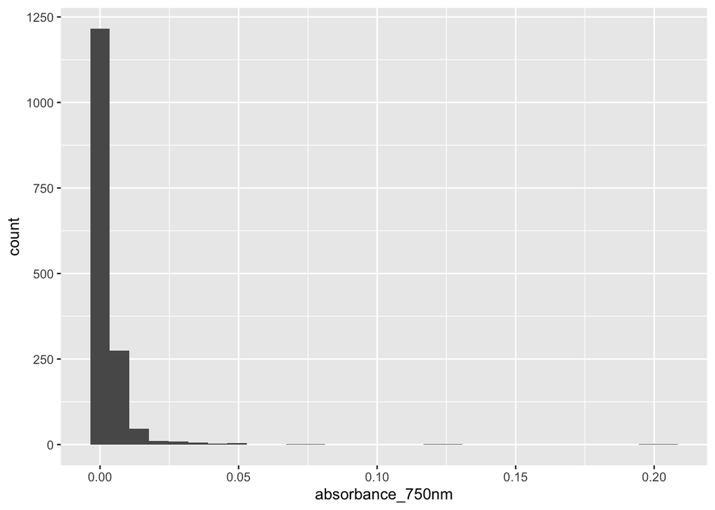

```r
ggplot() +
  geom_histogram(data = chl_a_messy, aes(x = absorbance_750nm))
```

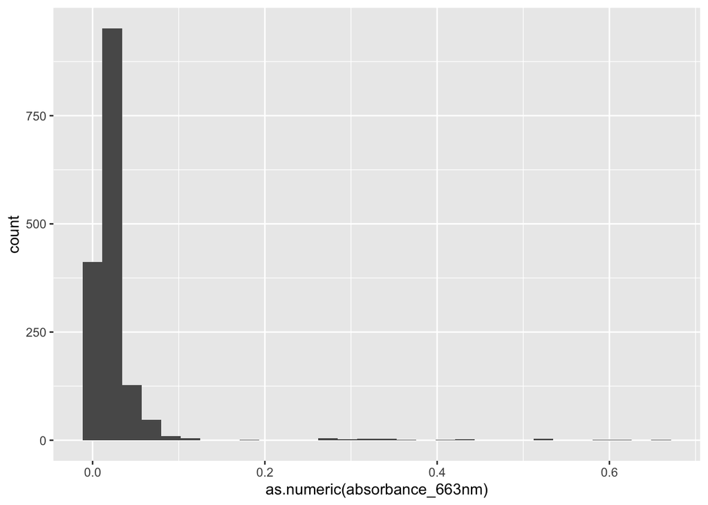

```r
ggplot() +
  geom_histogram(data = chl_a_messy, aes(x = as.numeric(absorbance_663nm))) # I'm coercing the variable to 'numeric' inside the plot only, just so I can see the distribution
```

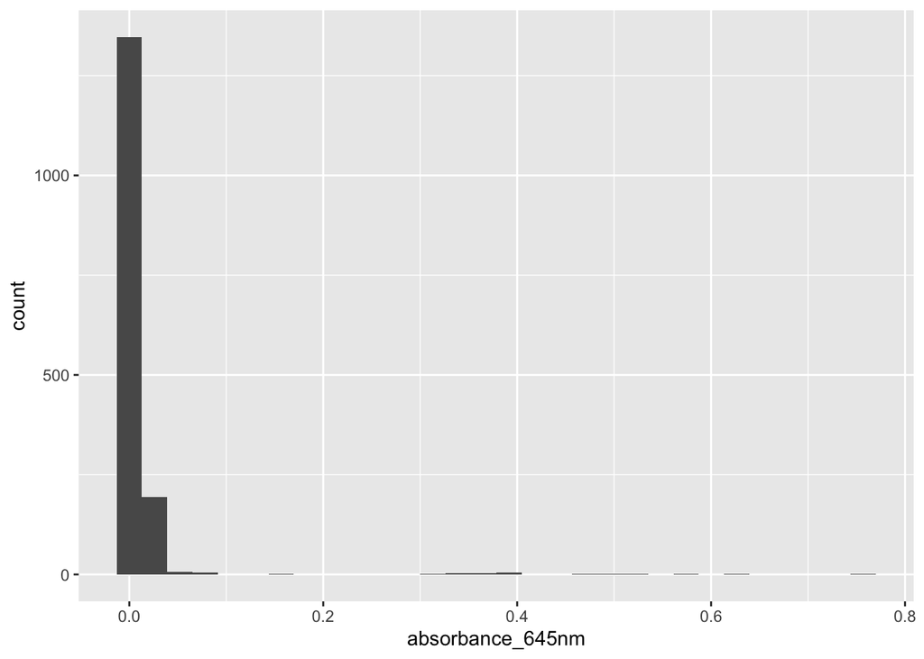

```r
ggplot() +
  geom_histogram(data = chl_a_messy, aes(x = absorbance_645nm))
```

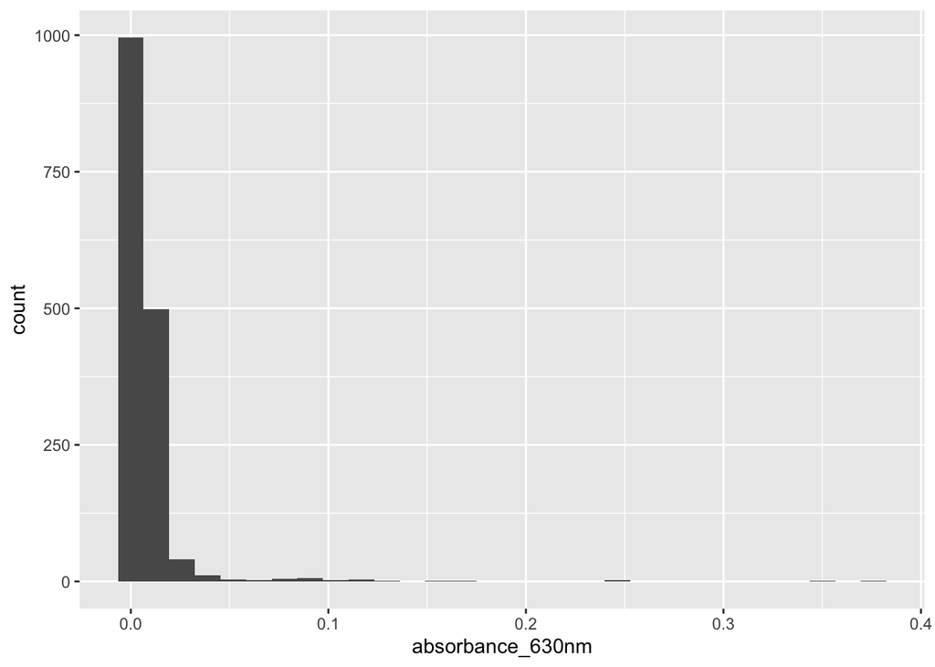

```r
ggplot() +
  geom_histogram(data = chl_a_messy, aes(x = absorbance_630nm))
```

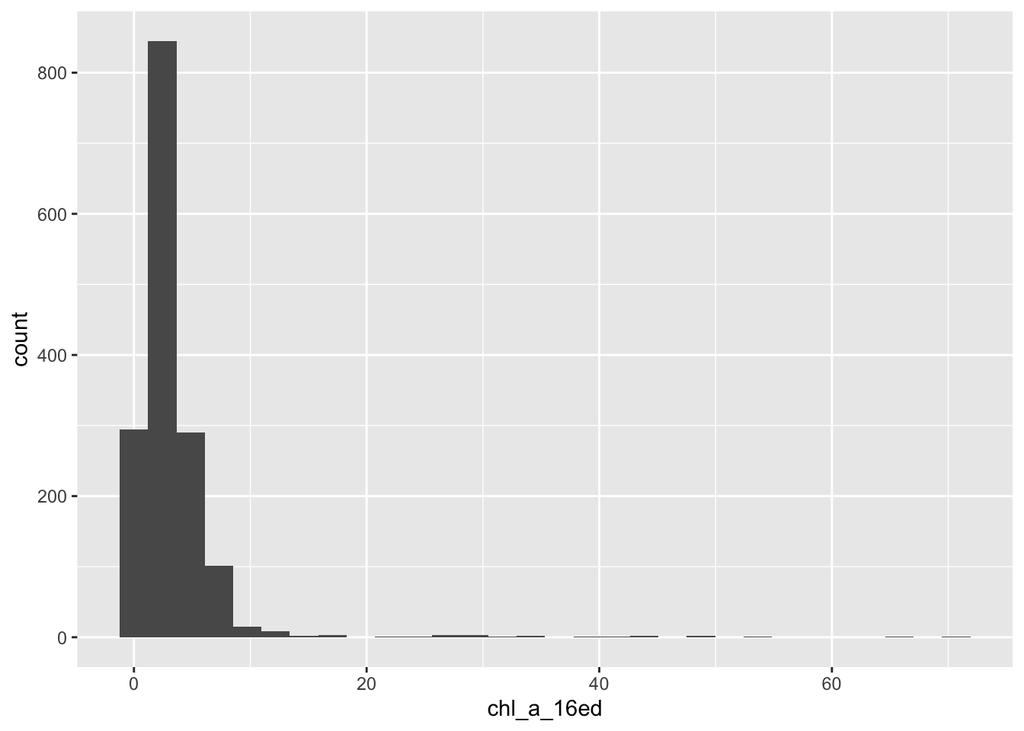

```r
ggplot() +
  geom_histogram(data = chl_a_messy, aes(x = chl_a_16ed))
```

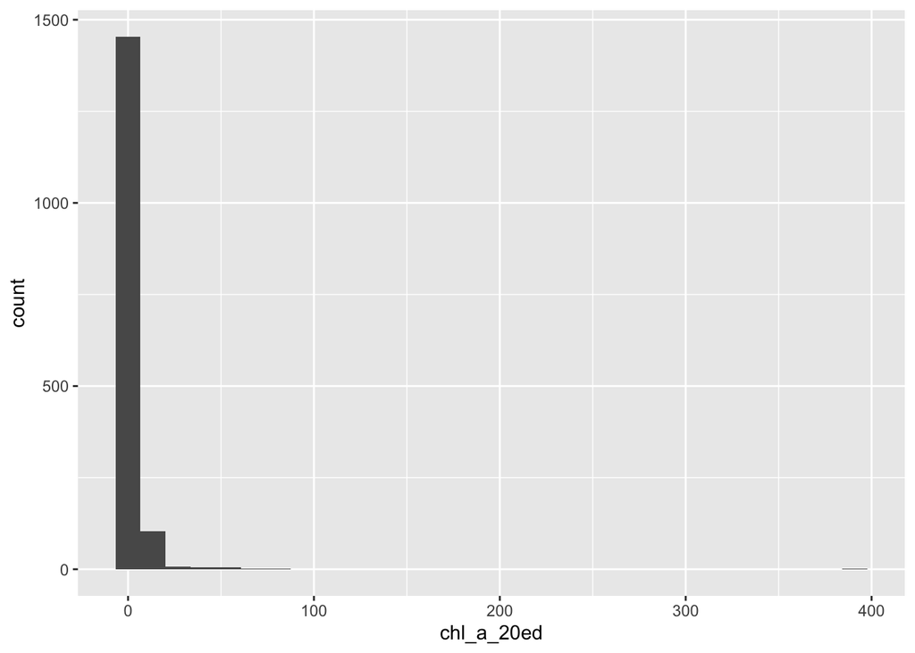

```r
ggplot() +
  geom_histogram(data = chl_a_messy, aes(x = chl_a_20ed))
```

SUMMARY *extract_volume_ml* There is a negative value, which I also identified with the skim() command above. This must be a typo as these values should all be positive based on the Data Dictionary.

*sample_volume_filtered_ml* There is a value around 10,000 which is likely a typo because a value this large doesn’t make sense based on the Data Dictionary. I also had to coerce this variable to numeric, resulting in a warning message. This tells me there is likely a comma or a letter accidentally included in one of the entries that I will have to correct.

*absorbance_750nm* This distribution looks alright, although there is potentially an outlier around 0.20. I will formally check for outliers in a later step.

*absorbance_663nm* This distribution looks alright. I also had to coerce this variable to numeric, resulting in a warning message. This tells me there is likely a comma or a letter accidentally included in one of the entries that I will have to correct.

*absorbance_645nm* This distribution looks alright, but I will formally check for outliers in a later step.

*absorbance_630nm* This distribution looks alright, but I will formally check for outliers in a later step.

*chl_a_16ed* This distribution looks alright, although there could be outliers around 65 and 70. I will formally check for outliers in a later step.

*chl_a_20ed* There is a value around 400, which is potentially a typo and likely an outlier. I will formally check for outliers in a later step.